# Exploring Steiner IBD Model Data

#### 5.3 Heatmap

**For heatmaps, as we want to compare the relative expression between conditions, it’s better to use Z-scores of our log2 transformed RPM counts which have been normalized.

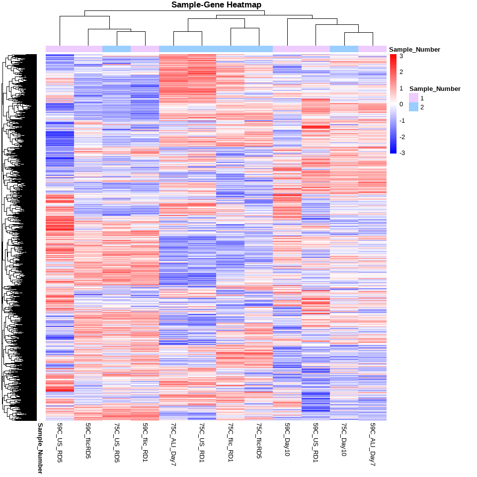

```r
#as we want the z-score per gene, and not per sample, we need to transpose the df so that genes are in columns, and samples in rows, as the scale function performs the function on columns

#z-score of log2RPM-RLE for heatmaps
t_eNorm <- as.data.frame(t(eNorm_log2))
eNorm_scale <- scale(t_eNorm, center = TRUE, scale = TRUE)
eNorm_scale <- as.data.frame(t(eNorm_scale))
#write.xlsx(eNorm_scale, file = here::here("data", "Processed", "ibd_eNorm_z-scores.xlsx"), col.names = TRUE, row.names = TRUE)


#finding out the max value of our eNorm_scale
range <- max(abs(eNorm_scale))
#setting colour white in our heatmaps to 0
breaks <- seq(-range, range, length.out = 100)

heatmap_cols = colorRampPalette(c("blue", "white", "red"))(99)

h2 <- eNorm_scale %>%
  pheatmap(clustering_distance_cols = "euclidean", clustering_method = "complete", cluster_rows = TRUE, show_colnames = TRUE, show_rownames = FALSE, color = heatmap_cols, breaks = breaks,
    main = "Sample-Gene Heatmap", annotation_row = pDat[c("Sample_Number")],
    annotation_col = pDat[c("Sample_Number")],
    annotation_colors = annot_cols)
```

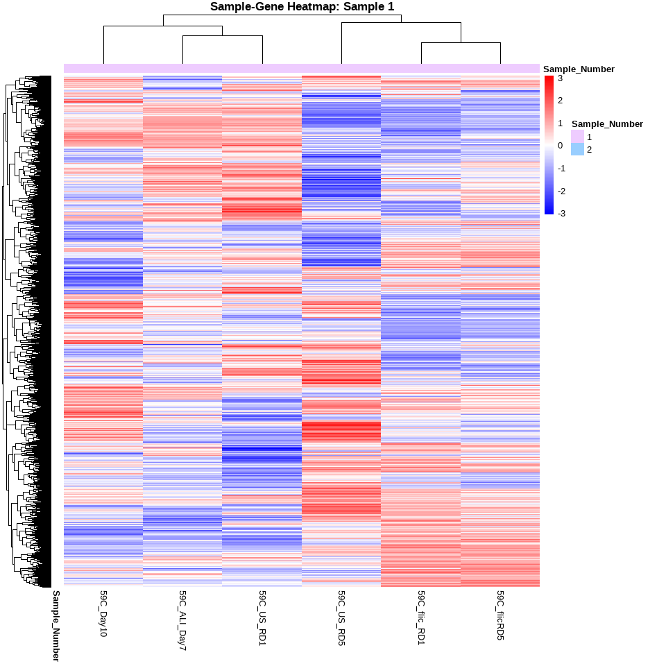

```r
eNorm_scale[c(1,3,5,7,9,11)] %>%
   pheatmap(clustering_distance_cols = "euclidean", clustering_method = "complete", cluster_rows = TRUE, show_colnames = TRUE, show_rownames = FALSE, color = heatmap_cols, breaks = breaks,
    main = "Sample-Gene Heatmap: Sample 1", annotation_row = pDat[c("Sample_Number")],
    annotation_col = pDat[c("Sample_Number")],
    annotation_colors = annot_cols)
```

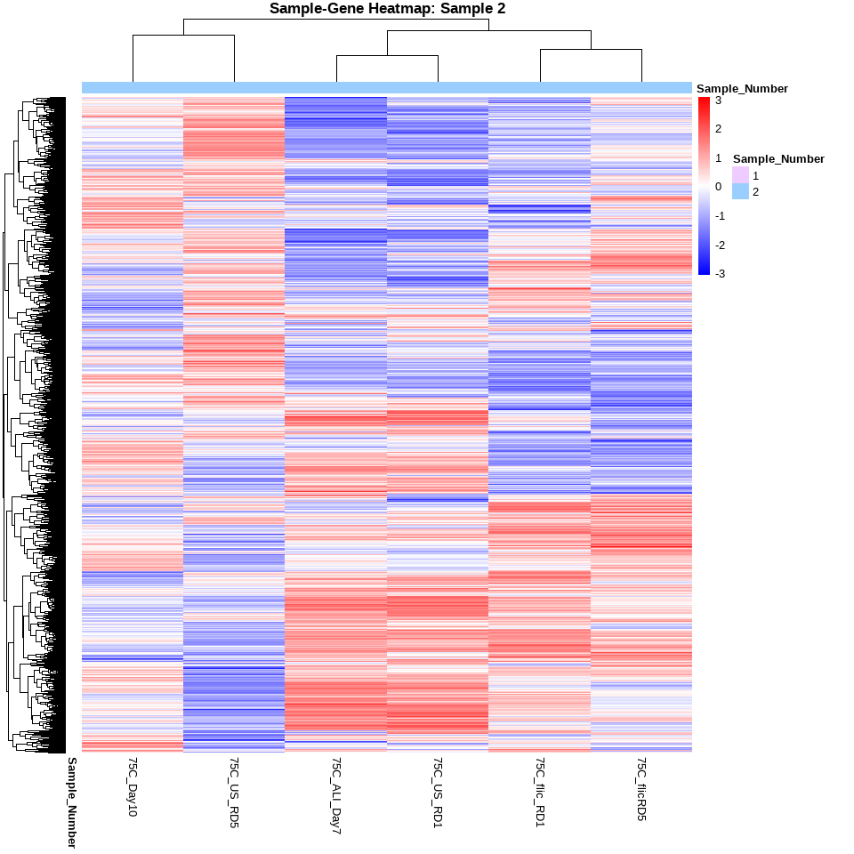

```r
eNorm_scale[c(2,4,6,8,10,12)] %>%
   pheatmap(clustering_distance_cols = "euclidean", clustering_method = "complete", cluster_rows = TRUE, show_colnames = TRUE, show_rownames = FALSE, color = heatmap_cols, breaks = breaks,
    main = "Sample-Gene Heatmap: Sample 2", annotation_row = pDat[c("Sample_Number")],
    annotation_col = pDat[c("Sample_Number")],
    annotation_colors = annot_cols)
```

#### 5.3 Sample Distribution

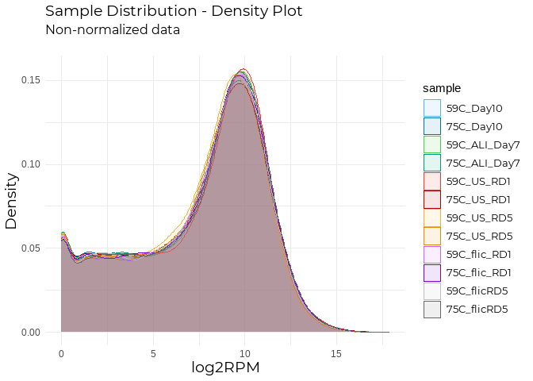

```r
e_melt <- melt(eNorm_log2)
colnames (e_melt) <- c("sample", "expression")
raw_melt <- melt(eDat)
colnames (raw_melt) <- c("sample", "expression")

samp_cols = c("#56B4E9", "#0072B2", "#47d147", "#009E73", "#ff3333" ,"#b30000", "#ffad33", "#e68a00", "#c266ff", "#7a00cc", "#bfbfbf" ,"#666666")

#density plots

raw_melt %>%
  ggplot(aes(log2(expression), color = sample, fill = sample)) +
  geom_density(alpha = 0.1) +
  # theme(legend.position = "bottom", legend.text = element_text(size = 17)) +
  theme(legend.position = c(.95, .95),legend.justification = c("right", "top")) +
  scale_fill_manual(values = samp_cols) +
  scale_colour_manual(values = samp_cols) +
  my_theme +
  #guides(color = guide_legend(nrow = 2)) +
  labs(x = "log2RPM", y = "Density", title = "Sample Distribution - Density Plot", subtitle = "Non-normalized data\n")
```

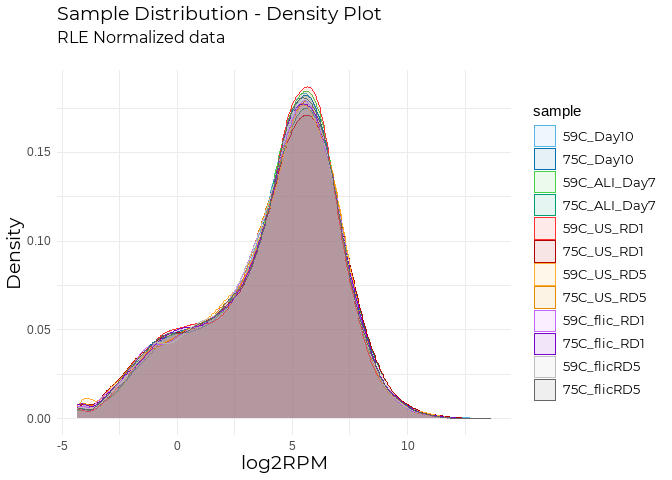

```r
e_melt %>%
  ggplot(aes(expression, color = sample, fill = sample)) +
  geom_density(alpha = 0.1) +
  # theme(legend.position = "bottom", legend.text = element_text(size = 17)) +
  theme(legend.position = c(.95, .95),legend.justification = c("right", "top")) +
  scale_fill_manual(values = samp_cols) +
  scale_colour_manual(values = samp_cols) +
  my_theme +
  #guides(color = guide_legend(nrow = 2)) +
  labs(x = "log2RPM", y = "Density", title = "Sample Distribution - Density Plot", subtitle = "RLE Normalized data\n")
```

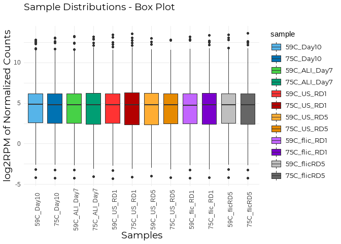

```r
#boxplot of normalized
e_melt %>%
  ggplot(aes(x = sample, y = expression, fill=sample)) +
  geom_boxplot() +
  scale_fill_manual(values = samp_cols) +
  my_theme +
  theme(axis.text.x = element_text(angle = 90)) +
  labs(x = "Samples", y = "log2RPM of Normalized Counts", title = "Sample Distributions - Box Plot\n")
```

### 6.0 PCA

```r
#on eNorm
t_eLog <- as.data.frame(t(eNorm_log2))

pca <- prcomp(t_eLog, scale=FALSE, center=TRUE) #n has to be less than number of samples

scores <- pca$x

pca_scores <- pca$x %>%
  as_tibble() %>%
  mutate(Sample_Name = row.names(pDat))

mDat <- cbind(pDat, pca_scores)

#on raw
# raw_log <- log2(raw)
# t_raw <- as.data.frame(t(log2(eDat)))
# pca_raw <- prcomp(t_raw, scale=FALSE, center=TRUE) #n has to be less than number of samples
# scores_raw <- pca_raw$x
# pca_scores_raw <- pca_raw$x %>%
#   as_tibble() %>%
#   mutate(Sample_Name = row.names(pDat))
# metaraw <- cbind(pDat, pca_scores_raw)
```

#### PC1 versus PC2

##### Samples

Using the RLE normalized read counts, and not the raw data (however both look similar)

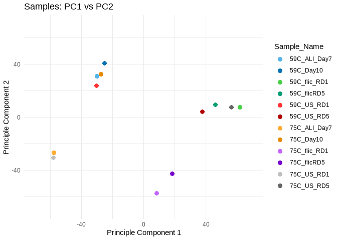

```r
mDat %>%
  ggplot(aes(x = PC1, y = PC2, colour = Sample_Name)) +
  geom_point(size = 3) +
  coord_cartesian(ylim = c(-70, 70), xlim = c(-70, 70)) +
  labs( x = "Principle Component 1", y = "Principle Component 2", title = "Samples: PC1 vs PC2") +
  scale_colour_manual(values = samp_cols) +
  theme_minimal()
```

##### Condition

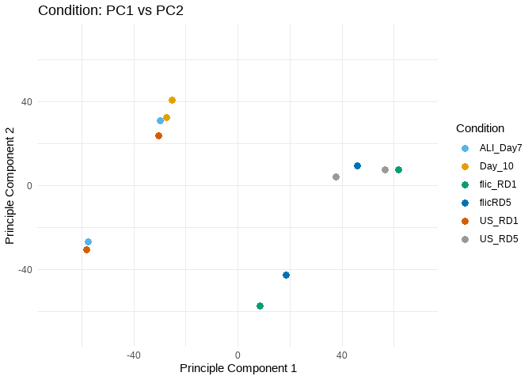

```r
mDat %>%
  ggplot(aes(x = PC1, y = PC2, colour = Condition)) +
  geom_point(size = 3) +
  coord_cartesian(ylim = c(-70, 70), xlim = c(-70, 70)) +
  labs( x = "Principle Component 1", y = "Principle Component 2", title = "Condition: PC1 vs PC2") +
  scale_colour_manual(values = cbPalette) +
  theme_minimal()
```

##### Sample Number / Sex

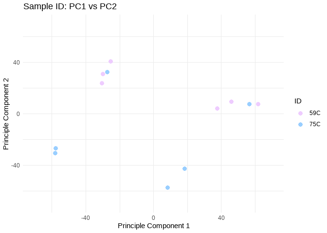

```r
mDat %>%
  ggplot(aes(x = PC1, y = PC2, colour = ID)) +
  geom_point(size = 3) +
  coord_cartesian(ylim = c(-70, 70), xlim = c(-70, 70)) +
  labs( x = "Principle Component 1", y = "Principle Component 2", title = "Sample ID: PC1 vs PC2") +
  scale_colour_manual(values = sex_col) +
  theme_minimal()
```

### 7.0 DEGs

```r
res_all2 <- map(res_all, function(x) x %>% dplyr::arrange(padj))

res_all2 <- map(res_all2, head, 10)

res_all3 <- Reduce(intersect, list(res_all2, "GeneName"))
#no common de genes

res_all3 <- map(res_all2, function (x) x %>% dplyr::select(GeneName))
res_all3 <- rbindlist(res_all3, idcol = TRUE)

res_all3 %>%
  dplyr::count(GeneName) %>%
  arrange(desc(n))
```

```
##         GeneName n
##  1:          REN 5
##  2:         TFF2 5
##  3:        FCGBP 4
##  4:          CA9 3
##  5:          CKB 3
##  6:        EGLN3 3
##  7:      SLC11A2 3
##  8:     C15orf48 2
##  9:        CCL20 2
## 10:        CDHR1 2
## 11:      CEACAM6 2
## 12:        FABP6 2
## 13:         GPX3 2
## 14:       HSD3B2 2
```

[output cut: 47 more lines]

```r
res_all3 %>%
  filter(GeneName == "REN" | GeneName == "TFF2")
```

```
##             .id GeneName
##  1:   d10_alid7     TFF2
##  2:   d10_alid7      REN
##  3: d10_flicRD1     TFF2
##  4: d10_flicRD1      REN
##  5: d10_flicRD5      REN
##  6: d10_flicRD5     TFF2
##  7:     d10_RD1      REN
##  8:     d10_RD1     TFF2
##  9:     d10_RD5      REN
## 10:     d10_RD5     TFF2
```

The REN and TFF2 genes are the 2 showing DE in 5 of the 9 conditions. Let’s look at the raw counts, and plot the change in expression.

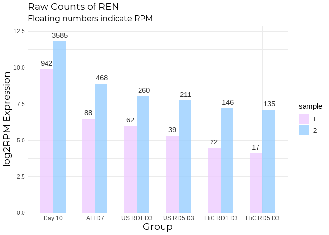

```r
#eNorm <- eNorm %>%
 # rownames_to_column(var = "gene")

#Plotting counts for REN
REN <- map(raw, function(x) x %>% filter(gene == "REN"))
REN <- rbindlist(REN, fill = TRUE) #otherwise NAs values get deleted
REN <- as.data.frame(t(REN))
REN <- REN[-1,]
REN <- REN %>%
  rownames_to_column(var = "group")
REN <- melt(REN, id.vars = "group")
REN <- na.omit(REN)
REN <- REN %>%
  distinct(group, .keep_all = TRUE) #cause same reading multiple times as each individual csv contains counts of the comparisons.
REN$sample <- c("1", "2")
REN$original <- REN$group
REN$original <- str_sub(REN$original, 6)
REN$original <- as.factor(REN$original)
REN$original <- fct_relevel(REN$original, c("Day.10", "ALI.D7", "US.RD1.D3", "US.RD5.D3", "FliC.RD1.D3", "FliC.RD5.D3")) #from undamaged --> most undamaged
REN$value <- as.numeric(REN$value)

REN %>%
  ggplot(aes(x = original, y = log2(value), fill = sample)) +
  geom_bar(stat = "identity", position = position_dodge(), alpha = 0.8, width = 0.6) +
  geom_text(aes(label = value), vjust = -0.8, colour = "#333333", position = position_dodge(0.65)) +
  scale_fill_manual(values = sex_col) +
 # coord_cartesian(y = c(0,15)) +
  scale_y_continuous(expand = expansion(mult = c(0, .09))) +
  labs(x = "Group", y = "log2RPM Expression", title = "Raw Counts of REN", subtitle = "Floating numbers indicate RPM") +
  my_theme
```

However, we should really compare the normalized counts.

```r
eNorm <- eNorm %>%
  rownames_to_column(var = "gene")

pDat <- pDat %>%
  rownames_to_column(var = "group")

REN_norm <- eNorm %>%
  filter(gene == "REN")
REN_norm <- as.data.frame(t(REN_norm))
REN_norm <- REN_norm %>%
  rownames_to_column(var = "group")
colnames(REN_norm) <- REN_norm[1,]
REN_norm <- REN_norm[-1,]
REN_norm <- REN_norm %>%
  inner_join(pDat, by = c("gene" = "group"))
REN_norm$REN <- as.numeric(REN_norm$REN)
REN_norm$REN <- round(REN_norm$REN, digits = 0)
REN_norm$Condition <- as.factor(REN_norm$Condition)
REN_norm$Condition <- fct_relevel(REN_norm$Condition, c("Day_10", "ALI_Day7", "US_RD1", "US_RD5", "flic_RD1", "flicRD5"))
str(REN_norm)
```

```
## 'data.frame':    12 obs. of  8 variables:
##  $ gene         : chr  "59C_Day10" "75C_Day10" "59C_ALI_Day7" "75C_ALI_Day7" ...
##  $ REN          : num  51 5 3 2 1 1 229 26 14 12 ...
##  $ Sample_Number: chr  "1" "2" "1" "2" ...
##  $ Sex          : chr  "Female" "Male" "Female" "Male" ...
##  $ Age          : chr  "49" "58" "49" "58" ...
##  $ Biopsy_Region: chr  "Transverse" "Ascending" "Transverse" "Ascending" ...
##  $ Condition    : Factor w/ 6 levels "Day_10","ALI_Day7",..: 1 1 2 2 3 3 4 4 5 5 ...
##  $ ID           : Factor w/ 2 levels "59C","75C": 1 2 1 2 1 2 1 2 1 2 ...
```

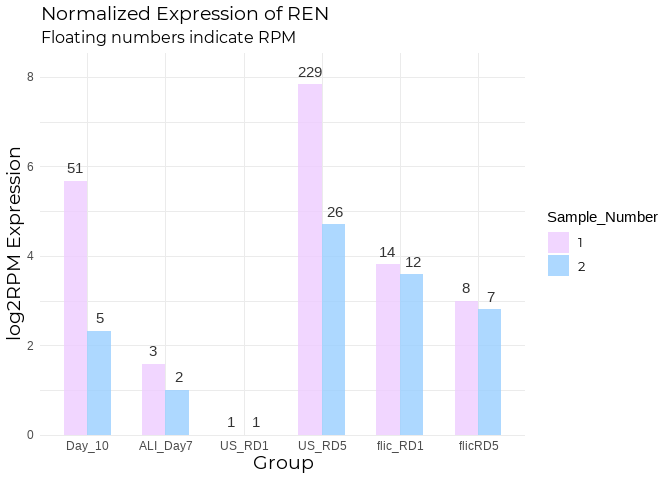

```r
REN_norm %>%
  ggplot(aes(x = Condition, y = log2(REN), fill = Sample_Number)) +
  geom_bar(stat = "identity", position = position_dodge(), alpha = 0.8, width = 0.6) +
  geom_text(aes(label = REN), vjust = -0.8, colour = "#333333", position = position_dodge(0.65)) +
  scale_fill_manual(values = sex_col) +
  #coord_cartesian(y = c(0,250)) +
  scale_y_continuous(expand = expansion(mult = c(0, .09))) +
  labs(x = "Group", y = "log2RPM Expression", title = "Normalized Expression of REN", subtitle = "Floating numbers indicate RPM") +
  my_theme
```

```r
TFF2_norm <- eNorm %>%
  filter(gene == "TFF2")
TFF2_norm <- as.data.frame(t(TFF2_norm))
TFF2_norm <- TFF2_norm %>%
  rownames_to_column(var = "group")
colnames(TFF2_norm) <- c("group", "count")
TFF2_norm <- TFF2_norm[-1,]
TFF2_norm <- TFF2_norm %>%
  inner_join(pDat, by = "group")
TFF2_norm$count <- as.numeric(TFF2_norm$count)
TFF2_norm$count <- round(TFF2_norm$count, digits = 0)
TFF2_norm$Condition <- as.factor(TFF2_norm$Condition)
TFF2_norm$Condition <- fct_relevel(TFF2_norm$Condition, c("Day_10", "ALI_Day7", "US_RD1", "US_RD5", "flic_RD1", "flicRD5"))
str(TFF2_norm)
```

```
## 'data.frame':    12 obs. of  8 variables:
##  $ group        : chr  "59C_Day10" "75C_Day10" "59C_ALI_Day7" "75C_ALI_Day7" ...
##  $ count        : num  545 49 52 49 19 35 442 31 21 25 ...
##  $ Sample_Number: chr  "1" "2" "1" "2" ...
##  $ Sex          : chr  "Female" "Male" "Female" "Male" ...
##  $ Age          : chr  "49" "58" "49" "58" ...
##  $ Biopsy_Region: chr  "Transverse" "Ascending" "Transverse" "Ascending" ...
##  $ Condition    : Factor w/ 6 levels "Day_10","ALI_Day7",..: 1 1 2 2 3 3 4 4 5 5 ...
##  $ ID           : Factor w/ 2 levels "59C","75C": 1 2 1 2 1 2 1 2 1 2 ...
```

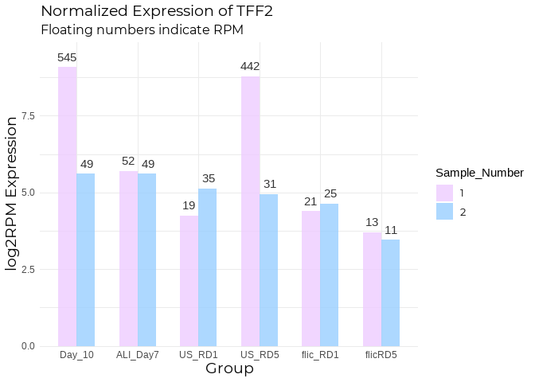

```r
TFF2_norm %>%
  ggplot(aes(x = Condition, y = log2(count), fill = Sample_Number)) +
  geom_bar(stat = "identity", position = position_dodge(), alpha = 0.8, width = 0.6) +
  geom_text(aes(label = count), vjust = -0.8, colour = "#333333", position = position_dodge(0.65)) +
  scale_fill_manual(values = sex_col) +
  #coord_cartesian(y = c(0,600)) +
  scale_y_continuous(expand = expansion(mult = c(0, .09))) +
  labs(x = "Group", y = "log2RPM Expression", title = "Normalized Expression of TFF2", subtitle = "Floating numbers indicate RPM") +
  my_theme
```

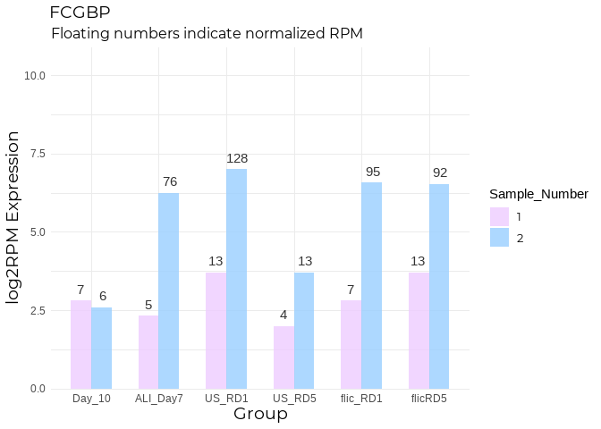

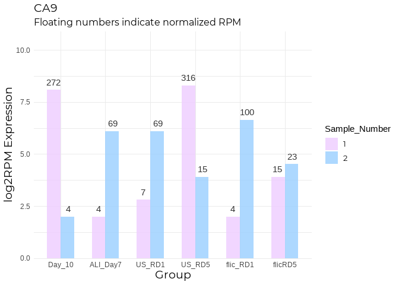

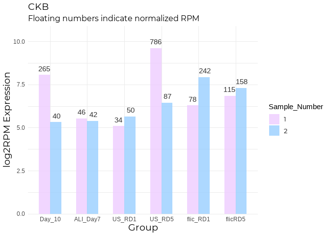

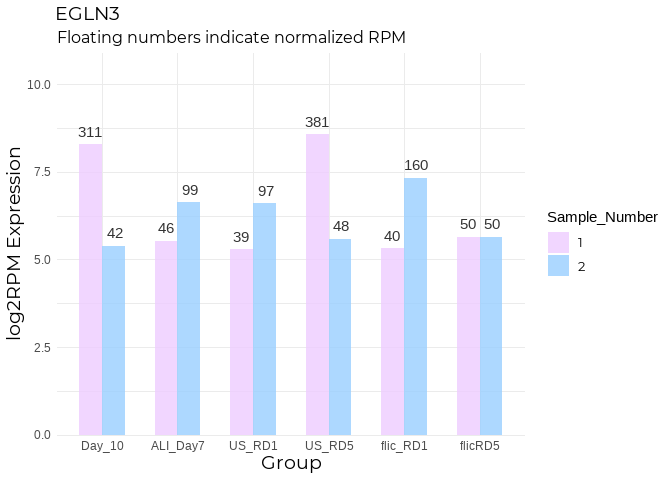

```r
FCGBP   <- eNorm %>% filter(gene == "FCGBP")
CA9 <- eNorm %>% filter(gene == "CA9")
CKB <- eNorm %>% filter(gene == "CKB")
EGLN3 <- eNorm %>% filter(gene == "EGLN3")

deg_names <- c("FCGBP", "CA9", 'CKB', "EGLN3")

degs <- list(FCGBP, CA9, CKB, EGLN3)
names(degs) <- deg_names

deg_formatting <- function (x) {
  x <- as.data.frame(t(x))
  x <- x %>%
    rownames_to_column(var = "group")
  colnames(x) <- c("group", "count")
  x <- x[-1,]
  x <- x %>%
    inner_join(pDat, by = "group")
  x$count <- as.numeric(x$count)
  x$count <- round(x$count, digits = 0)
  x$Condition <- as.factor(x$Condition)
  x$Condition <- fct_relevel(x$Condition, c("Day_10", "ALI_Day7", "US_RD1", "US_RD5", "flic_RD1", "flicRD5"))
  return(x)
}

degs <- map(degs, function(x) x %>% deg_formatting())
deg_plots <- list()

for (i in seq_along(degs)) {
  x <- ggplot(degs[[i]], (aes(x = Condition, y = log2(count), fill = Sample_Number))) +
    geom_bar(stat = "identity", position = position_dodge(), alpha = 0.8, width = 0.6) +
    geom_text(aes(label = count), vjust = -0.8, colour = "#333333", position = position_dodge(0.65)) +
    scale_fill_manual(values = sex_col) +
    coord_cartesian(y = c(0,10)) +
    scale_y_continuous(expand = expansion(mult = c(0, .09))) +
    labs(x = "Group", y = "log2RPM Expression", subtitle = "Floating numbers indicate normalized RPM") +
    ggtitle(names(degs[i])) +
    my_theme
  deg_plots[[i]] <- x
}

deg_plots
```

```r
deg2 <- c("TFF", "DKK1", "LOXL4", "GPX3", "GSTA1", "OTC", "LCN2", "UBD", "DUOX2", "CCL20", "HSD3B2", "LOC101928100", "ANKRD1")
#12

deg2 <- eNorm %>%
  filter(gene %in% deg2)

deg2
```

```
##            gene   59C_Day10  75C_Day10 59C_ALI_Day7 75C_ALI_Day7 59C_US_RD1
## 1        HSD3B2   1.6325924   3.767055     3.676230   52.7351280   4.568690
## 2          DKK1  87.1804361  30.028813    12.446663    3.6144301   8.785942
## 3        ANKRD1   8.2718017   9.417638     2.730913    1.3628179   1.907805
## 4         LOXL4  41.9576256  12.754173     3.623712    0.6517825   1.054313
## 5  LOC101928100  13.8770357  23.032853    42.066570    6.1030541  66.120489
## 6         DUOX2 117.2201369  17.489900    17.435832   43.4324144  87.206750
## 7         CCL20  27.5363924  18.996722    16.753103   15.6427795  89.516198
## 8          GPX3 717.3611163 142.017986   127.932790   21.2125571  45.285255
## 9           UBD  16.4891836   9.901974    16.648068    3.5551772  63.359193
## 10        GSTA1   0.8162962  11.516426    11.921487   41.3585611  16.818803
## 11         LCN2 132.7297650 100.903268    83.397894   41.4178140 509.283404
## 12          OTC   2.0679504  26.692278    17.645902   71.7553259  39.963485
##      75C_US_RD1   59C_US_RD5 75C_US_RD5 59C_flic_RD1 75C_flic_RD1 59C_flicRD5
## 1   25.41335791   0.12777978   2.544466    1.3831741   58.8282570    3.073184
```

[output cut: 24 more lines]